# HousePredict

Sujal Bhavsar

12/12/2019

```r
train<-read.csv('trainsujal.csv')
test<-read.csv('testsujal.csv')
train<- subset(train,select=-X)
test<- subset(test,select=-X)
ncol(train)
```

```
## [1] 71
```

```r
ncol(test)
```

```
## [1] 70
```

```r
combi <- rbind(subset(train,select=-logSalePrice),test)
combi
```

[output not shown]

[output cut: 15705 more lines]

```r
nrow(combi)
```

```
## [1] 2916
```

```r
combi$MSSubClass <- as.factor(combi$MSSubClass)
combi$OverallQual <- as.factor(combi$OverallQual)
combi$YearBuilt <- as.factor(combi$YearBuilt)
combi$YearRemodAdd <- as.factor(combi$YearRemodAdd)
combi$BsmtFullBath <- as.factor(combi$BsmtFullBath)
combi$BsmtHalfBath <- as.factor(combi$BsmtHalfBath)
combi$BedroomAbvGr <- as.factor(combi$BedroomAbvGr)
combi$KitchenAbvGr <- as.factor(combi$KitchenAbvGr)
combi$TotRmsAbvGrd <- as.factor(combi$TotRmsAbvGrd)
combi$Fireplaces <- as.factor(combi$Fireplaces)
combi$GarageYrBlt <- as.factor(combi$GarageYrBlt)
combi$GarageCars <- as.factor(combi$GarageCars)
combi$MoSold <- as.factor(combi$MoSold)
combi$YrSold <- as.factor(combi$YrSold)
```

Training and testing set are combined to dealth with some of the parameters transformation. Such as, numerical categorical variables are passed with as.factor.

After required transformation, the combined data is agains split into training and testing data based on their sample size.

```r
train_nw<-combi[1:1457,]
test_nw<- combi[1458:2916,]
train_nw['logSalePrice']<-train['logSalePrice']

attach(train_nw)
attach(test_nw)
```

Full Model check in R

```r
fit1<- lm(logSalePrice~.,data=train_nw)
summary(fit1)
```

```
##
## Call:
## lm(formula = logSalePrice ~ ., data = train_nw)
##
## Residuals:
##     Min      1Q  Median      3Q     Max
## -0.6207 -0.0384  0.0000  0.0427  0.3578
##
## Coefficients: (9 not defined because of singularities)
##                        Estimate Std. Error t value Pr(>|t|)
## (Intercept)           8.682e+00  5.432e-01  15.984  < 2e-16 ***
## MSSubClass30         -4.761e-02  2.878e-02  -1.654 0.098425 .
## MSSubClass40         -4.235e-03  7.031e-02  -0.060 0.951983
## MSSubClass45         -4.986e-02  1.111e-01  -0.449 0.653651
## MSSubClass50         -3.071e-03  4.544e-02  -0.068 0.946119
## MSSubClass60         -3.239e-02  3.924e-02  -0.826 0.409277
## MSSubClass70         -3.616e-02  4.539e-02  -0.797 0.425835
## MSSubClass75         -7.843e-02  1.051e-01  -0.746 0.455911
## MSSubClass80          1.304e-02  5.495e-02   0.237 0.812445
## MSSubClass85          3.511e-03  5.668e-02   0.062 0.950625
## MSSubClass90         -5.731e-02  4.343e-02  -1.320 0.187267
## MSSubClass120        -6.699e-02  7.284e-02  -0.920 0.357960
## MSSubClass160        -1.100e-01  8.729e-02  -1.260 0.207957
## MSSubClass180        -3.084e-02  9.641e-02  -0.320 0.749128
## MSSubClass190         4.218e-01  2.197e-01   1.920 0.055147 .
## MSZoningFV            5.570e-01  6.287e-02   8.860  < 2e-16 ***
## MSZoningRH            4.874e-01  6.718e-02   7.255 8.52e-13 ***
## MSZoningRL            5.080e-01  5.574e-02   9.113  < 2e-16 ***
## MSZoningRM            4.525e-01  5.341e-02   8.472  < 2e-16 ***
## LotFrontage           1.852e-02  1.750e-02   1.058 0.290240
## LotArea               7.618e-02  1.386e-02   5.497 5.00e-08 ***
## LotShapeIR2           8.183e-04  1.998e-02   0.041 0.967337
## LotShapeIR3           4.486e-02  3.909e-02   1.148 0.251363
## LotShapeReg           9.830e-03  7.744e-03   1.269 0.204623
## LandContourHLS        5.885e-03  2.670e-02   0.220 0.825608
## LandContourLow        9.261e-03  3.323e-02   0.279 0.780537
## LandContourLvl       -6.109e-03  2.030e-02  -0.301 0.763465
## LotConfigCulDSac      3.593e-02  1.590e-02   2.260 0.024082 *
## LotConfigFR2         -3.778e-02  1.861e-02  -2.030 0.042606 *
## LotConfigFR3         -5.856e-02  5.505e-02  -1.064 0.287774
```

[output cut: 502 more lines]

```
## SaleTypeCWD           5.521e-02  6.587e-02   0.838 0.402161
## SaleTypeNew           1.168e-01  7.259e-02   1.609 0.107860
## SaleTypeOth           3.398e-02  7.396e-02   0.459 0.646070
## SaleTypeWD           -3.461e-02  2.050e-02  -1.689 0.091610 .
## SaleConditionAdjLand  2.230e-01  8.022e-02   2.779 0.005555 **
## SaleConditionAlloca  -4.227e-02  5.199e-02  -0.813 0.416390
## SaleConditionFamily   2.923e-03  2.870e-02   0.102 0.918903
## SaleConditionNormal   7.263e-02  1.400e-02   5.188 2.61e-07 ***
## SaleConditionPartial -5.141e-02  6.938e-02  -0.741 0.458851
## ---
## Signif. codes:  0 '***' 0.001 '**' 0.01 '*' 0.05 '.' 0.1 ' ' 1
##
## Residual standard error: 0.09472 on 925 degrees of freedom
## Multiple R-squared:  0.9643, Adjusted R-squared:  0.9439
## F-statistic:  47.1 on 531 and 925 DF,  p-value: < 2.2e-16
```

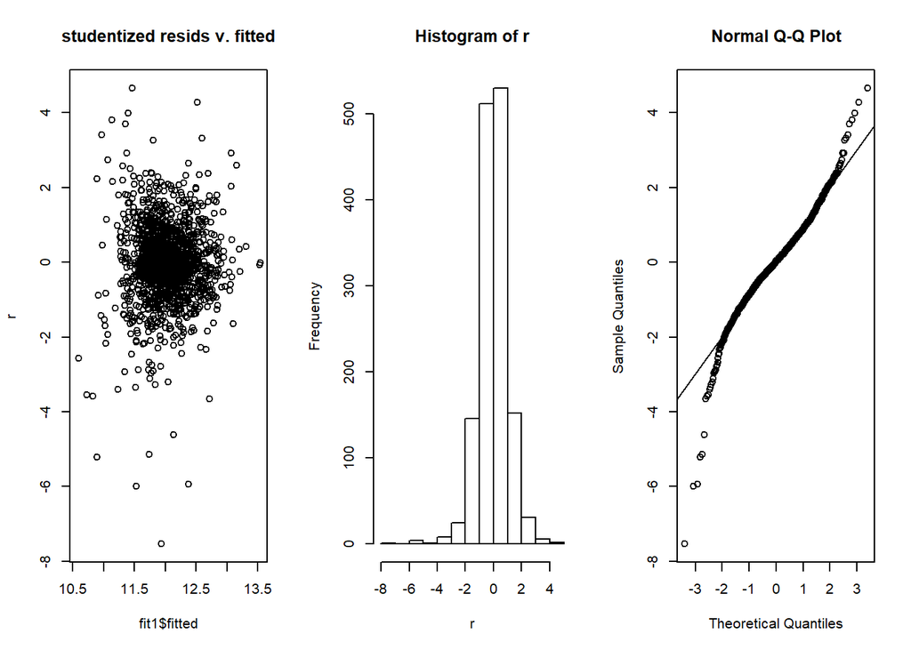

```r
r <- rstudent(fit1)
par(mfrow=c(1,3))
plot(fit1$fitted, r, main="studentized resids v. fitted")
hist(r)
qqnorm(r); abline(0,1)
```

Some levels of certain parameters are different in testing and training set. Also from the full model summary, it reveals that those column had no statistical significance. Hence, I found it appropriate to drop that out for making prediction on testing data.

```r
## Some of the levels are missing from testing set. also from the summary it reveals that those column had no statistical significance

train_nw1<- subset(train_nw,select=-c(MSSubClass,YearBuilt,BsmtFullBath,BsmtHalfBath,TotRmsAbvGrd,Fireplaces, GarageYrBlt, GarageCars))
test_nw1<- subset(test_nw,select=-c(MSSubClass,YearBuilt,BsmtFullBath,BsmtHalfBath, TotRmsAbvGrd, Fireplaces, GarageYrBlt, GarageCars))
fit2<- lm(logSalePrice~.,data=train_nw1)
summary(fit2)
```

```
##
## Call:
## lm(formula = logSalePrice ~ ., data = train_nw1)
##
## Residuals:
##      Min       1Q   Median       3Q      Max
## -0.66231 -0.04594  0.00254  0.05042  0.40809
##
## Coefficients: (1 not defined because of singularities)
##                        Estimate Std. Error t value Pr(>|t|)
## (Intercept)           7.566e+00  4.271e-01  17.715  < 2e-16 ***
## MSZoningFV            4.656e-01  5.401e-02   8.621  < 2e-16 ***
## MSZoningRH            4.717e-01  5.412e-02   8.716  < 2e-16 ***
## MSZoningRL            4.395e-01  4.595e-02   9.564  < 2e-16 ***
## MSZoningRM            4.206e-01  4.278e-02   9.831  < 2e-16 ***
## LotFrontage           1.159e-02  1.608e-02   0.721 0.471219
## LotArea               9.040e-02  1.205e-02   7.500 1.26e-13 ***
## LotShapeIR2           5.370e-03  1.915e-02   0.280 0.779243
## LotShapeIR3           2.713e-02  3.900e-02   0.696 0.486841
## LotShapeReg           1.252e-02  7.266e-03   1.723 0.085103 .
## LandContourHLS        1.970e-02  2.332e-02   0.845 0.398485
## LandContourLow       -1.849e-02  2.851e-02  -0.648 0.516880
## LandContourLvl        1.891e-03  1.677e-02   0.113 0.910276
## LotConfigCulDSac      2.896e-02  1.479e-02   1.958 0.050424 .
## LotConfigFR2         -4.808e-02  1.807e-02  -2.661 0.007899 **
## LotConfigFR3         -8.340e-02  5.569e-02  -1.497 0.134559
## LotConfigInside      -1.208e-02  8.017e-03  -1.507 0.132005
## LandSlopeMod          1.338e-02  1.818e-02   0.736 0.461928
## LandSlopeSev         -5.888e-02  4.093e-02  -1.438 0.150572
## NeighborhoodBlueste  -3.527e-02  9.156e-02  -0.385 0.700165
## NeighborhoodBrDale   -4.225e-02  5.191e-02  -0.814 0.415876
## NeighborhoodBrkSide  -4.720e-02  4.176e-02  -1.130 0.258567
## NeighborhoodClearCr  -2.497e-02  4.273e-02  -0.584 0.559158
## NeighborhoodCollgCr  -6.262e-02  3.351e-02  -1.869 0.061918 .
## NeighborhoodCrawfor   4.428e-02  3.873e-02   1.143 0.253157
## NeighborhoodEdwards  -1.398e-01  3.634e-02  -3.847 0.000126 ***
## NeighborhoodGilbert  -4.319e-02  3.606e-02  -1.198 0.231342
## NeighborhoodIDOTRR   -1.216e-01  4.790e-02  -2.538 0.011263 *
## NeighborhoodMeadowV  -1.480e-01  5.242e-02  -2.823 0.004842 **
## NeighborhoodMitchel  -9.766e-02  3.784e-02  -2.581 0.009987 **
```

[output cut: 258 more lines]

```
## SaleTypeCWD           4.716e-02  5.927e-02   0.796 0.426427
## SaleTypeNew           1.257e-01  6.841e-02   1.837 0.066414 .
## SaleTypeOth           5.978e-02  6.545e-02   0.913 0.361225
## SaleTypeWD           -3.400e-02  1.927e-02  -1.764 0.077988 .
## SaleConditionAdjLand  1.530e-01  7.359e-02   2.079 0.037819 *
## SaleConditionAlloca   5.908e-02  4.114e-02   1.436 0.151269
## SaleConditionFamily   1.618e-02  2.723e-02   0.594 0.552594
## SaleConditionNormal   6.961e-02  1.292e-02   5.389 8.59e-08 ***
## SaleConditionPartial -4.116e-02  6.517e-02  -0.632 0.527804
## ---
## Signif. codes:  0 '***' 0.001 '**' 0.01 '*' 0.05 '.' 0.1 ' ' 1
##
## Residual standard error: 0.09974 on 1161 degrees of freedom
## Multiple R-squared:  0.9504, Adjusted R-squared:  0.9377
## F-statistic: 75.34 on 295 and 1161 DF,  p-value: < 2.2e-16
```

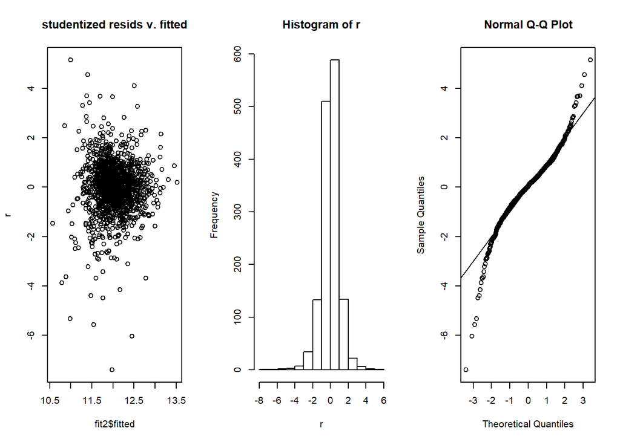

```r
r <- rstudent(fit2)
par(mfrow=c(1,3))
plot(fit2$fitted, r, main="studentized resids v. fitted")
hist(r)
qqnorm(r); abline(0,1)
```

```r
p1<-predict(fit2,test_nw1,interval='prediction')
```

Adjusted R-squred for fit2 is 0.9377

Residual diagnositc are quite similar to fit1. Nothing much concerning.

Got RMSE value of 0.13619 on the testing set from fit 2

```r
## use BIC with step to reduce the model

null<-lm(logSalePrice~1,data=train_nw)
full<-lm(logSalePrice~.,data=train_nw)
n <- nrow(train_nw)
fit3<- step(null,scope=formula(full),direction='forward',k=log(n),trace=0)
summary(fit3)
```

```
##
## Call:
## lm(formula = logSalePrice ~ OverallQual + GrLivArea + Neighborhood +
##     TotalBsmtSF + OverallCond + BsmtUnfSF + GarageArea + SaleCondition +
##     CentralAir + LotArea + Foundation + MSZoning + GarageFinish +
##     KitchenQual + ScreenPorch + Functional + BsmtQual + HalfBath +
##     firstFlrSf + secondFlrSf + BsmtExposure + KitchenAbvGr +
##     FullBath, data = train_nw)
##
## Residuals:
##      Min       1Q   Median       3Q      Max
## -0.69688 -0.05239  0.00652  0.05864  0.53607
##
## Coefficients:
##                        Estimate Std. Error t value Pr(>|t|)
## (Intercept)           7.993e+00  3.101e-01  25.777  < 2e-16 ***
## OverallQual2          9.585e-02  1.023e-01   0.937 0.348949
## OverallQual3          1.986e-01  8.639e-02   2.299 0.021642 *
## OverallQual4          2.483e-01  8.435e-02   2.943 0.003300 **
## OverallQual5          2.863e-01  8.478e-02   3.377 0.000753 ***
## OverallQual6          3.381e-01  8.504e-02   3.975 7.39e-05 ***
## OverallQual7          3.967e-01  8.551e-02   4.639 3.83e-06 ***
## OverallQual8          4.592e-01  8.631e-02   5.320 1.21e-07 ***
## OverallQual9          5.574e-01  8.903e-02   6.260 5.12e-10 ***
## OverallQual10         5.659e-01  9.219e-02   6.139 1.08e-09 ***
## GrLivArea             4.027e-05  3.769e-05   1.068 0.285513
## NeighborhoodBlueste  -3.127e-02  8.416e-02  -0.372 0.710298
## NeighborhoodBrDale   -4.889e-02  4.569e-02  -1.070 0.284744
## NeighborhoodBrkSide  -4.217e-02  3.617e-02  -1.166 0.243880
## NeighborhoodClearCr  -2.306e-02  3.843e-02  -0.600 0.548508
## NeighborhoodCollgCr  -3.204e-02  3.047e-02  -1.051 0.293266
## NeighborhoodCrawfor   5.139e-02  3.479e-02   1.477 0.139920
## NeighborhoodEdwards  -1.109e-01  3.301e-02  -3.358 0.000806 ***
## NeighborhoodGilbert  -1.704e-02  3.227e-02  -0.528 0.597628
## NeighborhoodIDOTRR   -1.102e-01  4.157e-02  -2.651 0.008120 **
## NeighborhoodMeadowV  -1.621e-01  4.361e-02  -3.716 0.000210 ***
## NeighborhoodMitchel  -6.779e-02  3.438e-02  -1.972 0.048839 *
## NeighborhoodNAmes    -7.721e-02  3.210e-02  -2.405 0.016302 *
## NeighborhoodNoRidge   3.688e-03  3.541e-02   0.104 0.917074
## NeighborhoodNPkVill  -5.485e-02  4.764e-02  -1.151 0.249806
```

[output cut: 46 more lines]

```
## firstFlrSf            2.698e-01  4.388e-02   6.150 1.01e-09 ***
## secondFlrSf           1.912e-04  3.830e-05   4.991 6.76e-07 ***
## BsmtExposureGd        4.373e-02  1.298e-02   3.369 0.000774 ***
## BsmtExposureMn       -1.393e-02  1.300e-02  -1.071 0.284239
## BsmtExposureNo       -1.615e-02  9.088e-03  -1.777 0.075707 .
## KitchenAbvGr1         8.416e-02  1.269e-01   0.663 0.507456
## KitchenAbvGr2        -1.131e-02  1.274e-01  -0.089 0.929245
## KitchenAbvGr3         2.350e-02  1.495e-01   0.157 0.875125
## FullBath              3.550e-02  9.268e-03   3.830 0.000134 ***
## ---
## Signif. codes:  0 '***' 0.001 '**' 0.01 '*' 0.05 '.' 0.1 ' ' 1
##
## Residual standard error: 0.1079 on 1377 degrees of freedom
## Multiple R-squared:  0.9311, Adjusted R-squared:  0.9271
## F-statistic: 235.5 on 79 and 1377 DF,  p-value: < 2.2e-16
```

```r
# model probabilities

BIC<- data.frame(fit2=extractAIC(fit2,k=log(n))[2],fit3=extractAIC(fit3,k=log(n))[2])
eBIC<-exp(-.5*(BIC-min(BIC)))
round(probs<-eBIC/sum(eBIC),4)
```

```
##   fit2 fit3
## 1    0    1
```

Obtained reduced model through step

Got an adjustd R-squred of 0.9271

It is clear from model probability that the probability of the fit3 to be better than fit 2 is 100%.

```r
test_nw2<- subset(test_nw1,select=c(OverallQual, GrLivArea, Neighborhood,TotalBsmtSF, OverallCond, BsmtUnfSF, GarageArea,SaleCondition ,CentralAir , LotArea , Foundation , MSZoning , GarageFinish ,KitchenQual, ScreenPorch, Functional, BsmtQual, HalfBath ,firstFlrSf , secondFlrSf , BsmtExposure , KitchenAbvGr ,FullBath))

p2<-predict(fit3,test_nw2,interval='prediction')
#write.csv(exp(p2[,1]),'p2.csv')
```

Got RMSE value of 0.12681 on testing data from fit3

```r
# invovling interaction

fit4<- step(fit3, scope=~.+.^2, direction="forward", k=log(n), trace=0)
summary(fit4)
```

```
##
## Call:
## lm(formula = logSalePrice ~ OverallQual + GrLivArea + Neighborhood +
##     TotalBsmtSF + OverallCond + BsmtUnfSF + GarageArea + SaleCondition +
##     CentralAir + LotArea + Foundation + MSZoning + GarageFinish +
##     KitchenQual + ScreenPorch + Functional + BsmtQual + HalfBath +
##     firstFlrSf + secondFlrSf + BsmtExposure + KitchenAbvGr +
##     FullBath + CentralAir:firstFlrSf + OverallCond:BsmtExposure +
##     TotalBsmtSF:MSZoning + firstFlrSf:secondFlrSf + BsmtUnfSF:ScreenPorch +
##     GarageArea:KitchenAbvGr, data = train_nw)
##
## Residuals:
##      Min       1Q   Median       3Q      Max
## -0.69923 -0.05006  0.00470  0.05755  0.45054
##
## Coefficients: (1 not defined because of singularities)
##                              Estimate Std. Error t value Pr(>|t|)
## (Intercept)                 6.102e+00  3.959e-01  15.414  < 2e-16 ***
## OverallQual2                3.216e-01  1.031e-01   3.120 0.001846 **
## OverallQual3                2.077e-01  8.840e-02   2.349 0.018941 *
## OverallQual4                2.732e-01  8.669e-02   3.151 0.001661 **
## OverallQual5                3.119e-01  8.733e-02   3.571 0.000367 ***
## OverallQual6                3.568e-01  8.769e-02   4.069 4.99e-05 ***
## OverallQual7                4.153e-01  8.799e-02   4.720 2.60e-06 ***
## OverallQual8                4.774e-01  8.857e-02   5.390 8.28e-08 ***
## OverallQual9                5.677e-01  9.076e-02   6.255 5.29e-10 ***
## OverallQual10               5.818e-01  9.278e-02   6.271 4.80e-10 ***
## GrLivArea                   4.781e-05  3.851e-05   1.242 0.214585
## NeighborhoodBlueste        -4.689e-02  8.153e-02  -0.575 0.565330
## NeighborhoodBrDale         -4.939e-02  4.521e-02  -1.093 0.274778
## NeighborhoodBrkSide        -3.394e-02  3.486e-02  -0.974 0.330385
## NeighborhoodClearCr        -4.969e-03  3.708e-02  -0.134 0.893417
## NeighborhoodCollgCr        -3.228e-02  2.934e-02  -1.100 0.271409
## NeighborhoodCrawfor         4.994e-02  3.358e-02   1.487 0.137211
## NeighborhoodEdwards        -1.200e-01  3.178e-02  -3.776 0.000166 ***
## NeighborhoodGilbert        -2.570e-02  3.113e-02  -0.826 0.409070
## NeighborhoodIDOTRR         -8.328e-02  4.031e-02  -2.066 0.039007 *
## NeighborhoodMeadowV        -1.580e-01  4.272e-02  -3.699 0.000225 ***
## NeighborhoodMitchel        -6.549e-02  3.309e-02  -1.979 0.047987 *
## NeighborhoodNAmes          -7.622e-02  3.088e-02  -2.468 0.013699 *
```

[output cut: 61 more lines]

```
## TotalBsmtSF:MSZoningFV     -8.764e-04  1.732e-04  -5.060 4.76e-07 ***
## TotalBsmtSF:MSZoningRH     -8.993e-04  1.871e-04  -4.806 1.71e-06 ***
## TotalBsmtSF:MSZoningRL     -9.248e-04  1.674e-04  -5.525 3.94e-08 ***
## TotalBsmtSF:MSZoningRM     -8.420e-04  1.683e-04  -5.004 6.36e-07 ***
## firstFlrSf:secondFlrSf     -8.781e-05  2.665e-05  -3.295 0.001010 **
## BsmtUnfSF:ScreenPorch       4.186e-07  1.245e-07   3.361 0.000797 ***
## GarageArea:KitchenAbvGr1    1.079e-03  4.159e-04   2.595 0.009559 **
## GarageArea:KitchenAbvGr2    9.220e-04  4.189e-04   2.201 0.027910 *
## GarageArea:KitchenAbvGr3           NA         NA      NA       NA
## ---
## Signif. codes:  0 '***' 0.001 '**' 0.01 '*' 0.05 '.' 0.1 ' ' 1
##
## Residual standard error: 0.1037 on 1365 degrees of freedom
## Multiple R-squared:  0.9369, Adjusted R-squared:  0.9327
## F-statistic: 222.8 on 91 and 1365 DF,  p-value: < 2.2e-16
```

```r
#CentralAir:firstFlrSf + OverallCond:BsmtExposure + TotalBsmtSF:MSZoning + firstFlrSf:secondFlrSf + BsmtUnfSF:ScreenPorch + GarageArea:KitchenAbvGr,
# included theses interaction

# Model Probabilities
BIC<- data.frame(fit3=extractAIC(fit3,k=log(n))[2],fit4=extractAIC(fit4,k=log(n))[2])
eBIC<-exp(-.5*(BIC-min(BIC)))
round(probs<-eBIC/sum(eBIC),4)
```

```
##   fit3 fit4
## 1    0    1
```

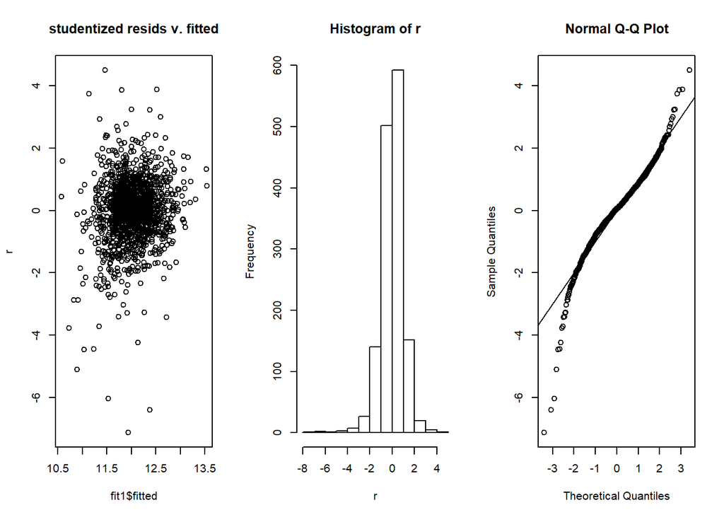

```r
# again fit4 seems promising let us check its residual diagnostic

r <- rstudent(fit4)
par(mfrow=c(1,3))
plot(fit1$fitted, r, main="studentized resids v. fitted")
hist(r)
qqnorm(r); abline(0,1)
```

```r
# NOthing much concerning on residual diagnostic

p4<-predict(fit4,test_nw2,interval='prediction')
#write.csv(exp(p4[,1]),'p4.csv')
```

Obtained R-squared: 0.9327

It is seen that fit4 is better than fit3 from model probability. However, its performance on the testing set is not better than fit3.

Residual diagnosis reveals nothing to be concern about

Got RMSE of 0.13815 with fit 4

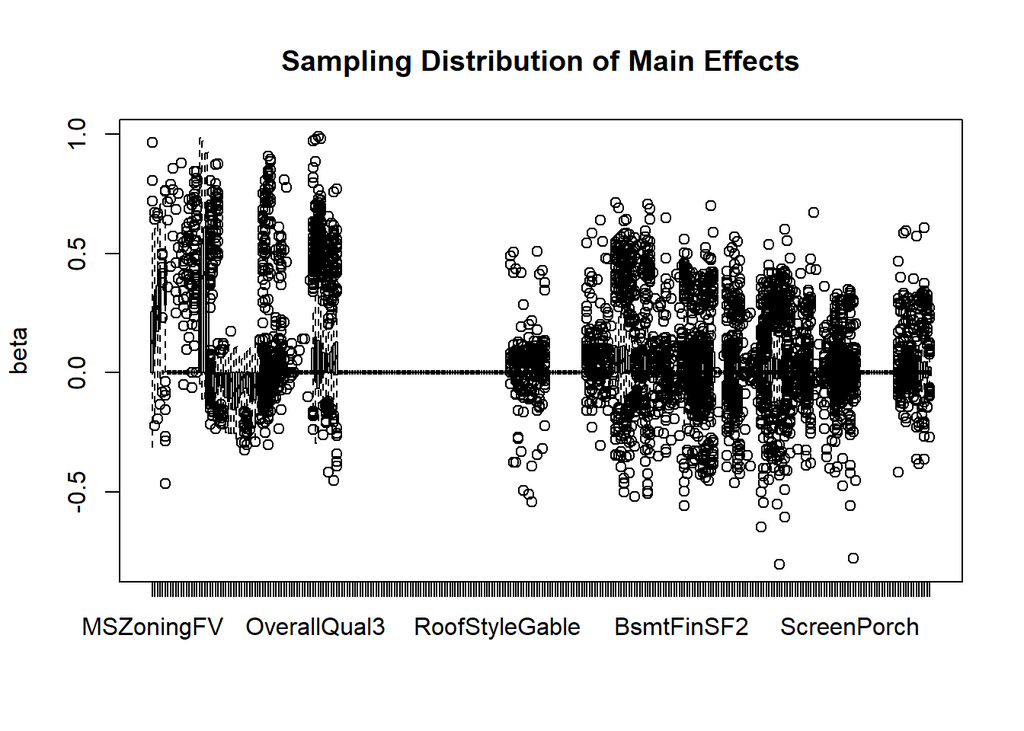

```r
bb<-read.csv('xx.csv')
B<-199
beta <- matrix(0,296, nrow=B)
colnames(beta)<-bb[,2]
# train_nw3<-as.matrix(train_nw1)
# fit5 <- lars(train_nw3[,1:62], train_nw3[,63], type="lasso")
# lassofit

for(b in 1:B) {
  index <- sample(1:nrow(train_nw1), nrow(train_nw1), replace=TRUE)
  XYT <- data.frame(SalePrice=train_nw1[index,63], train_nw1[index,1:62])
  null <- lm(SalePrice~1, data=XYT)
  full <- lm(SalePrice~., data=XYT)
  fwdbak <- step(null, scope=formula(full), trace=0, k=log(nrow(XYT)))
  beta[b,which(colnames(beta) %in% names(coef(fwdbak)[-1]))] <- coef(fwdbak)[-1]
}

par(mfrow=c(1,1))
boxplot(beta, xaxt="n", ylab="beta", main="Sampling Distribution of Main Effects")
axis(1, at=1:ncol(beta), labels=colnames(beta))
```

```r
##IT is very difficult to observe this variation

ps <- apply(beta, 2, function(x) { mean(x != 0)} )
ps
```

```
##           MSZoningFV           MSZoningRH           MSZoningRL
##          0.909547739          0.909547739          0.909547739
##           MSZoningRM          LotFrontage              LotArea
##          0.909547739          0.035175879          1.000000000
##          LotShapeIR2          LotShapeIR3          LotShapeReg
##          0.015075377          0.015075377          0.015075377
##       LandContourHLS       LandContourLow       LandContourLvl
##          0.020100503          0.020100503          0.020100503
##     LotConfigCulDSac         LotConfigFR2         LotConfigFR3
##          0.050251256          0.050251256          0.050251256
##      LotConfigInside         LandSlopeMod         LandSlopeSev
##          0.050251256          0.110552764          0.110552764
##  NeighborhoodBlueste   NeighborhoodBrDale  NeighborhoodBrkSide
##          0.597989950          0.693467337          0.693467337
##  NeighborhoodClearCr  NeighborhoodCollgCr  NeighborhoodCrawfor
##          0.693467337          0.693467337          0.693467337
##  NeighborhoodEdwards  NeighborhoodGilbert   NeighborhoodIDOTRR
##          0.693467337          0.693467337          0.693467337
##  NeighborhoodMeadowV  NeighborhoodMitchel    NeighborhoodNAmes
##          0.693467337          0.693467337          0.693467337
##  NeighborhoodNoRidge  NeighborhoodNPkVill  NeighborhoodNridgHt
##          0.693467337          0.693467337          0.693467337
##   NeighborhoodNWAmes  NeighborhoodOldTown   NeighborhoodSawyer
##          0.693467337          0.693467337          0.693467337
##  NeighborhoodSawyerW  NeighborhoodSomerst  NeighborhoodStoneBr
##          0.693467337          0.693467337          0.693467337
##    NeighborhoodSWISU   NeighborhoodTimber  NeighborhoodVeenker
##          0.693467337          0.693467337          0.693467337
##      Condition1Feedr       Condition1Norm       Condition1PosA
##          0.422110553          0.422110553          0.422110553
##       Condition1PosN       Condition1RRAe       Condition1RRAn
##          0.422110553          0.422110553          0.422110553
##       Condition1RRNe       Condition1RRNn       BldgType2fmCon
##          0.386934673          0.422110553          0.025125628
##       BldgTypeDuplex        BldgTypeTwnhs       BldgTypeTwnhsE
##          0.025125628          0.025125628          0.025125628
##     HouseStyle1.5Unf     HouseStyle1Story     HouseStyle2.5Fin
##          0.005025126          0.005025126          0.005025126
##     HouseStyle2.5Unf     HouseStyle2Story     HouseStyleSFoyer
##          0.005025126          0.005025126          0.005025126
```

[output cut: 143 more lines]

```
##          0.000000000          0.000000000          0.000000000
##             MoSold10             MoSold11             MoSold12
##          0.000000000          0.000000000          0.000000000
##           YrSold2007           YrSold2008           YrSold2009
##          0.000000000          0.000000000          0.000000000
##           YrSold2010          SaleTypeCon        SaleTypeConLD
##          0.000000000          0.140703518          0.150753769
##        SaleTypeConLI        SaleTypeConLw          SaleTypeCWD
##                   NA                   NA          0.150753769
##          SaleTypeNew          SaleTypeOth           SaleTypeWD
##          0.150753769          0.145728643          0.150753769
## SaleConditionAdjLand  SaleConditionAlloca  SaleConditionFamily
##          0.969849246          0.984924623                   NA
##  SaleConditionNormal SaleConditionPartial
##                   NA          0.984924623
```

```r
#overqual selected 100% of the time
```

For storing the values of particular parameters in beta matrix, I need to have all dummy variables assigned as a column name to my beta matrix. To handle this, I have made a separate csv file that contains the name of all parameters including dummies. colnames for beta

Since there are around ~300 parameters after including dummy one, It is extremely difficult to observe the boxplot of betas.

It was observed that ‘Overqual’ parameter was selected 100% of the time.

```r
combi_1 <- rbind(subset(train_nw1,select=-logSalePrice),test_nw1)

# converting to numeric categoy

mapping = c('Ex'=5,'Gd'=4,'TA'=3,'Fa'=2,'Po'=1,'None'=0)
ordinal_var = c('BsmtQual', 'BsmtCond', 'GarageQual', 'GarageCond', 'ExterQual', 'ExterCond', 'HeatingQC', 'KitchenQual')
combi_2<-combi_1
for (v in ordinal_var){
  combi_2[v] = c('Ex'=5,'Gd'=4,'TA'=3,'Fa'=2,'Po'=1,'None'=0)[combi_1[v][[1]]]
}
combi_2['BsmtFinType1'] = c('GLQ'=6,'ALQ'=5,'BLQ'=4,'Rec'=3,'LwQ'=2,'Unf'=1,'None'=0)[combi_1['BsmtFinType1'][[1]]]
combi_2['BsmtFinType2'] = c('GLQ'=6,'ALQ'=5,'BLQ'=4,'Rec'=3,'LwQ'=2,'Unf'=1,'None'=0)[combi_1['BsmtFinType2'][[1]]]
combi_2['Functional'] = c('Typ'=7,'Min1'=6,'Min2'=5,'Mod'=4,'Maj1'=3,'Maj2'=2,'Sev'=1,'Sal'=0)[combi_1['Functional'][[1]]]
combi_2['BsmtExposure'] = c('Gd'=4,'Av'=3,'Mn'=2,'No'=1,'None'=0)[combi_1['BsmtExposure'][[1]]]
combi_2['GarageFinish'] = c('None'=0, 'Unf'=1, 'RFn'=2, 'Fin'=3)[combi_1['GarageFinish'][[1]]]
combi_2['LandSlope'] = c('Sev'=1, 'Mod'=2, 'Gtl'=3)[combi_1['LandSlope'][[1]]]
combi_2['LotShape'] = c('IR3'=1, 'IR2'=2, 'IR1'=3, 'Reg'=4)[combi_1['LotShape'][[1]]]
combi_2['PavedDrive'] = c('N'=1, 'P'=2, 'Y'=3)[combi_1['PavedDrive'][[1]]]
combi_2['CentralAir'] = c('N'=0, 'Y'=1)[combi_1['CentralAir'][[1]]]

combi_2[combi_2 == 'None'] = 0
```

Converted all non-numerical category to a numerical one (working with combined testing and training dataset). Some of the parameters which were not possible to make numeric are extracted as a dummy variable.

```r
library(magrittr) # needs to be run every time you start R and want to use %>%
library(dplyr)
#
# # dummy variables
combi_2 = combi_2 %>%
  as.data.frame() %>%
  fastDummies::dummy_cols() %>%
  .[colnames(.)[sapply(., class) != "character"]]




for (v in colnames(combi_2)){
  x = combi_2[v][[1]]
  combi_2[v] = ifelse(is.na(as.numeric(x)), x, as.numeric(x))
}

combi_2[is.na(combi_2)]<-0

# Making standardized for lasso

for (v in colnames(combi_2)){
  combi_2[v] = (combi_2[v] - mean(combi_2[v][[1]])) / sd(combi_2[v][[1]])
}



combi_2[is.na(combi_2)]<-0




train_nw4<-combi_2[1:1457,]  #(this is only parameters)
test_nw4<- combi_2[1458:2916,]

#Lasso start for combi2
library(glmnet)
```

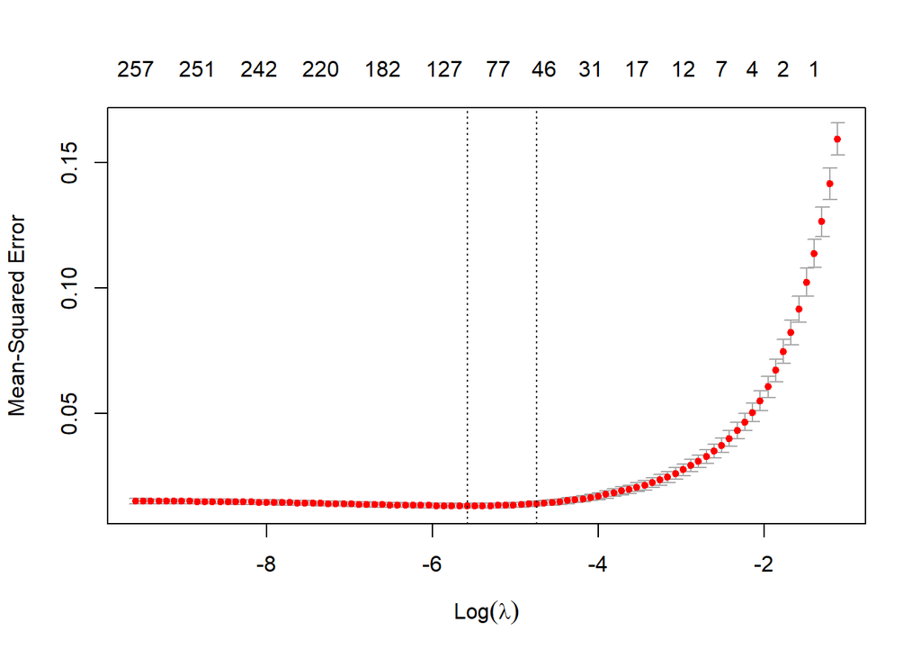

```r
cv.lasso1=cv.glmnet(as.matrix(train_nw4),train_nw1[,63],alpha=1,family='gaussian')
plot(cv.lasso1)
```

```r
sprintf('Best lambda for LASSO: %f.', cv.lasso1$lambda.min)
```

```
## [1] "Best lambda for LASSO: 0.003774."
```

```r
coef_lasso = coef(cv.lasso1, cv.lasso1$lambda.min) %>%
  as.matrix() %>%
  as.data.frame()
coef_lasso$abs = abs(coef_lasso[,1])

coef_lasso$abs %>%
  order(coef_lasso$abs, decreasing = TRUE) %>%
  coef_lasso[., ] %>%
  head(20) %>%
  dplyr::select(-'abs')
```

```
##                                1
## (Intercept)          12.01684831
## GrLivArea             0.11559386
## OverallQual           0.08989922
## TotalBsmtSF           0.05024060
## LotArea               0.03731656
## GarageArea            0.03639674
## MSZoning_C (all)     -0.03094159
## OverallCond           0.02895504
## YearRemodAdd          0.02420338
## BsmtFinSF1            0.01912200
## firstFlrSf            0.01854415
## CentralAir            0.01829314
## SaleCondition         0.01808946
## Functional           -0.01719301
## Neighborhood_Crawfor  0.01614207
## BsmtUnfSF            -0.01600855
## Foundation_PConc      0.01559617
## BsmtQual              0.01516576
## HeatingQC             0.01291081
## HalfBath              0.01258444
```

```r
#FInal model with lasso lambda min
lasso.model1 = glmnet(as.matrix(train_nw4),train_nw1[,63], family = "gaussian", lambda = cv.lasso1$lambda.min)

lasso_pre_tr = lasso.model1 %>% predict(newx = as.matrix(train_nw4))
sprintf('Training RMSE of LASSO: %f.', sqrt(mean((train_nw1[,63] - lasso_pre_tr)^2))) # training RMSE
```

```
## [1] "Training RMSE of LASSO: 0.103058."
```

```r
lasso_pre_te = lasso.model1 %>% predict(newx = as.matrix(test_nw4))
#write.csv(exp(lasso_pre_te),'p5.csv')
```

Min. value so λ is selected using the cv.glmnet function. And lasso model is trained using that λ value.

Got RMSE on testing set: 0.12740 with lasso

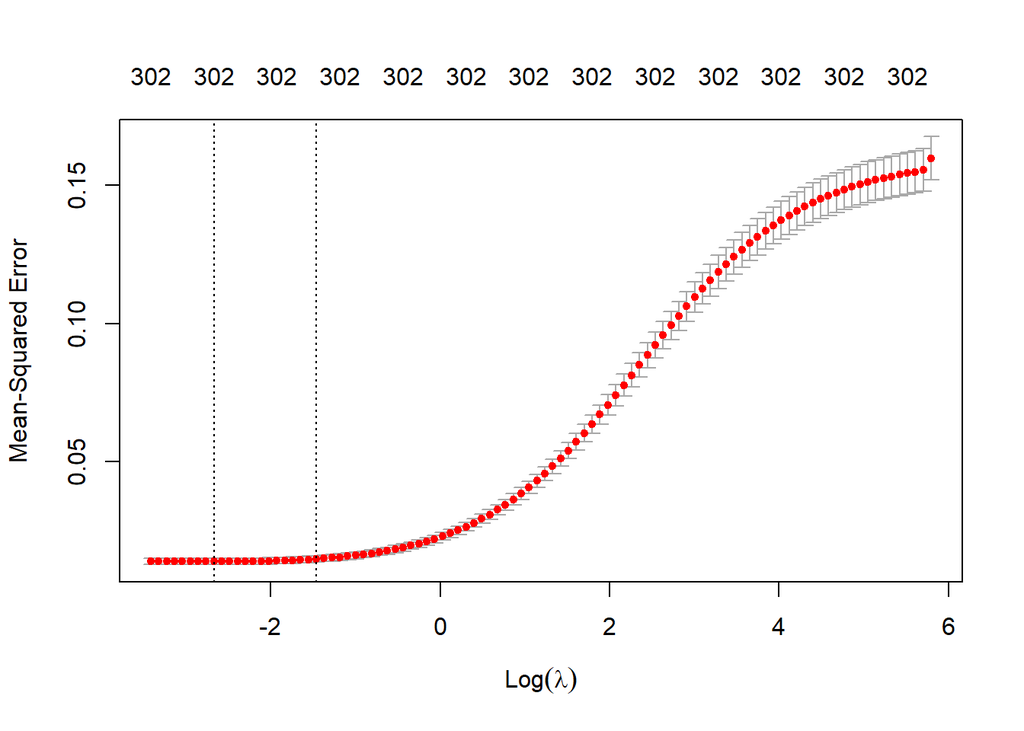

```r
#Ridge regression



cv.ridge=cv.glmnet(as.matrix(train_nw4),train_nw1[,63],alpha=0,family='gaussian')
plot(cv.ridge)
```

```r
sprintf('Best lambda for LASSO: %f.', cv.ridge$lambda.min)
```

```
## [1] "Best lambda for LASSO: 0.069085."
```

```r
coef_ridge = coef(cv.ridge, cv.ridge$lambda.min) %>%
  as.matrix() %>%
  as.data.frame()
coef_ridge$abs = abs(coef_ridge[,1])

coef_ridge$abs %>%
  order(coef_ridge$abs, decreasing = TRUE) %>%
  coef_ridge[., ] %>%
  head(20) %>%
  dplyr::select(-'abs')
```

```
##                                1
## (Intercept)          12.01649785
## GrLivArea             0.05028862
## firstFlrSf            0.04750314
## TotalBsmtSF           0.04401376
## OverallQual           0.03571825
## GarageArea            0.03335637
## LotArea               0.03329478
## MSZoning_C (all)     -0.02968620
## OverallCond           0.02707736
## secondFlrSf           0.02381363
## FullBath              0.02075839
## Neighborhood_Crawfor  0.01903942
## CentralAir            0.01864851
## BsmtFinSF1            0.01838535
## OverallQual_9         0.01805554
## OverallQual_8         0.01626292
## HalfBath              0.01558508
## BsmtQual              0.01511665
## Functional           -0.01457052
## Neighborhood_OldTown -0.01421852
```

```r
#FInal model with lasso lambda min
ridge.model = glmnet(as.matrix(train_nw4),train_nw1[,63],alpha = 0, family = "gaussian", lambda = cv.ridge$lambda.min)

ridge_pre_tr = ridge.model %>% predict(newx = as.matrix(train_nw4))
sprintf('Training RMSE of LASSO: %f.', sqrt(mean((train_nw1[,63] - ridge_pre_tr)^2))) # training RMSE
```

```
## [1] "Training RMSE of LASSO: 0.096914."
```

```r
ridge_pre_te = ridge.model %>% predict(newx = as.matrix(test_nw4))
#write.csv(exp(ridge_pre_te),'p6.csv')
```

Got RMSE on testing set with Ridge: 0.13110

```r
### BIC with interaction
null1<-lm(logSalePrice~1,data=train_nw)
full1<-lm(logSalePrice~OverallQual + GrLivArea*TotRmsAbvGrd + Neighborhood + TotalBsmtSF + OverallCond + BsmtUnfSF + GarageArea + SaleCondition + CentralAir + LotArea + Foundation + MSZoning + GarageFinish + KitchenQual + ScreenPorch + Functional + BsmtQual + HalfBath + firstFlrSf + secondFlrSf + BsmtExposure + KitchenAbvGr + FullBath+firstFlrSf*TotalBsmtSF+GarageArea*GarageCars,data=train_nw)
n <- nrow(train_nw)
fit7<- step(null1,scope=formula(full1),direction='forward',k=log(n),trace=0)
summary(fit7)
```

```
##
## Call:
## lm(formula = logSalePrice ~ OverallQual + GrLivArea + Neighborhood +
##     TotalBsmtSF + OverallCond + BsmtUnfSF + GarageArea + SaleCondition +
##     CentralAir + LotArea + Foundation + MSZoning + GarageFinish +
##     KitchenQual + ScreenPorch + Functional + BsmtQual + HalfBath +
##     firstFlrSf + secondFlrSf + BsmtExposure + KitchenAbvGr +
##     FullBath, data = train_nw)
##
## Residuals:
##      Min       1Q   Median       3Q      Max
## -0.69688 -0.05239  0.00652  0.05864  0.53607
##
## Coefficients:
##                        Estimate Std. Error t value Pr(>|t|)
## (Intercept)           7.993e+00  3.101e-01  25.777  < 2e-16 ***
## OverallQual2          9.585e-02  1.023e-01   0.937 0.348949
## OverallQual3          1.986e-01  8.639e-02   2.299 0.021642 *
## OverallQual4          2.483e-01  8.435e-02   2.943 0.003300 **
## OverallQual5          2.863e-01  8.478e-02   3.377 0.000753 ***
## OverallQual6          3.381e-01  8.504e-02   3.975 7.39e-05 ***
## OverallQual7          3.967e-01  8.551e-02   4.639 3.83e-06 ***
## OverallQual8          4.592e-01  8.631e-02   5.320 1.21e-07 ***
## OverallQual9          5.574e-01  8.903e-02   6.260 5.12e-10 ***
## OverallQual10         5.659e-01  9.219e-02   6.139 1.08e-09 ***
## GrLivArea             4.027e-05  3.769e-05   1.068 0.285513
## NeighborhoodBlueste  -3.127e-02  8.416e-02  -0.372 0.710298
## NeighborhoodBrDale   -4.889e-02  4.569e-02  -1.070 0.284744
## NeighborhoodBrkSide  -4.217e-02  3.617e-02  -1.166 0.243880
## NeighborhoodClearCr  -2.306e-02  3.843e-02  -0.600 0.548508
## NeighborhoodCollgCr  -3.204e-02  3.047e-02  -1.051 0.293266
## NeighborhoodCrawfor   5.139e-02  3.479e-02   1.477 0.139920
## NeighborhoodEdwards  -1.109e-01  3.301e-02  -3.358 0.000806 ***
## NeighborhoodGilbert  -1.704e-02  3.227e-02  -0.528 0.597628
## NeighborhoodIDOTRR   -1.102e-01  4.157e-02  -2.651 0.008120 **
## NeighborhoodMeadowV  -1.621e-01  4.361e-02  -3.716 0.000210 ***
## NeighborhoodMitchel  -6.779e-02  3.438e-02  -1.972 0.048839 *
## NeighborhoodNAmes    -7.721e-02  3.210e-02  -2.405 0.016302 *
## NeighborhoodNoRidge   3.688e-03  3.541e-02   0.104 0.917074
## NeighborhoodNPkVill  -5.485e-02  4.764e-02  -1.151 0.249806
```

[output cut: 46 more lines]

```
## firstFlrSf            2.698e-01  4.388e-02   6.150 1.01e-09 ***
## secondFlrSf           1.912e-04  3.830e-05   4.991 6.76e-07 ***
## BsmtExposureGd        4.373e-02  1.298e-02   3.369 0.000774 ***
## BsmtExposureMn       -1.393e-02  1.300e-02  -1.071 0.284239
## BsmtExposureNo       -1.615e-02  9.088e-03  -1.777 0.075707 .
## KitchenAbvGr1         8.416e-02  1.269e-01   0.663 0.507456
## KitchenAbvGr2        -1.131e-02  1.274e-01  -0.089 0.929245
## KitchenAbvGr3         2.350e-02  1.495e-01   0.157 0.875125
## FullBath              3.550e-02  9.268e-03   3.830 0.000134 ***
## ---
## Signif. codes:  0 '***' 0.001 '**' 0.01 '*' 0.05 '.' 0.1 ' ' 1
##
## Residual standard error: 0.1079 on 1377 degrees of freedom
## Multiple R-squared:  0.9311, Adjusted R-squared:  0.9271
## F-statistic: 235.5 on 79 and 1377 DF,  p-value: < 2.2e-16
```

```r
# seens like interaction is of no use
```